# R Notebook

```r
print("create an new tildy")
```

```
[1] "create an new tildy"
```

so from here we will do all the codes and answer of introduction to statistical learning and push this to git first basic vector creation ,and other basic programming vector are being created in R using c()

```r
a=c(1,2,3,4,4)
b=c(23,32,1,2,12)
print(a+b)
```

```
[1] 24 34  4  6 16
```

ls()command will give you total no of object present

```r
ls()
```

```
[1] "a"         "as"        "b"         "filt"      "kick_data"
[6] "us_data"   "x"         "y"
```

now here it being showing more objects as i was working bi nine thing before

```r
library(dplyr)
library(ggplot2)
library(statsr)
```

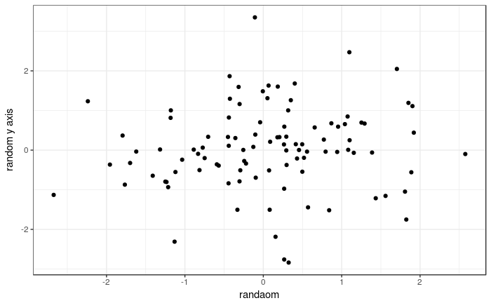

```r
app=rnorm(100)
app1=rnorm(100)
a=data_frame(app,app1)
ggplot(data = a,aes(x=app,y=app1))+geom_point()+theme_bw()+xlab("randaom")+ylab("random y axis")
```

```r
pdf("figure.pdf")
ggplot(data=a,aes(x=app,y=app1))+geom_point()
dev.off()
```

```r
as=seq(1,23,length=10)
as
```

```
 [1]  1.000000  3.444444  5.888889  8.333333 10.777778 13.222222
 [7] 15.666667 18.111111 20.555556 23.000000
```

seq function can also be used to make a list or vector of 10 element in the range of [1,23]

```r
Auto=read.csv("Auto.csv",na.strings = "?")
fix(Auto)
dim(Auto)
```

```
[1] 397   9
```

```r
Auto=na.omit(Auto)
```

```r
dim(Auto)
```

```
[1] 392   9
```

as you can see we had just omitted all those data which have missing value so the no of observation get reduced its good to omit only when we are not having to much say (10% ) data removed

```r
names(Auto)
```

```
[1] "mpg"          "cylinders"    "displacement" "horsepower"
[5] "weight"       "acceleration" "year"         "origin"
[9] "name"
```

names function give us the name of all these columns

```r
library(ggplot2)
plot1=ggplot(data = Auto,aes(x=cylinders,y=mpg))+geom_point()+xlab("No of cylinders")+ylab("Milage")
library(plotly)
ggplotly(plot1)
```

```
We recommend that you use the dev version of ggplot2 with `ggplotly()`
Install it with: `devtools::install_github('hadley/ggplot2')`
```

[interactive chart not shown]

as we can see that mileage is getting decreased as the no. of cylinders in an vechile is increasing lets see the correlation between them

```r
cor(Auto$mpg,Auto$cylinders)
```

```
[1] -0.7776175
```

as we can see that there is a very strong correlation between the no of cylinders and the mileage of the vehicles also since there are only limited no of element or discrete values the no off cylinders can take so can be make categorical cylinders=as.factor(cylinders)

```r
Auto$cylinders=as.factor(Auto$cylinders)
```

```r
ggplot(data=Auto,aes(x=cylinders,y=mpg))+geom_boxplot()+theme_gray()
```

[output not shown]

here after making cylinder categorical we can use it to make a categorical plot and also keep in mind that for box plot we need a categorical and one numerical data

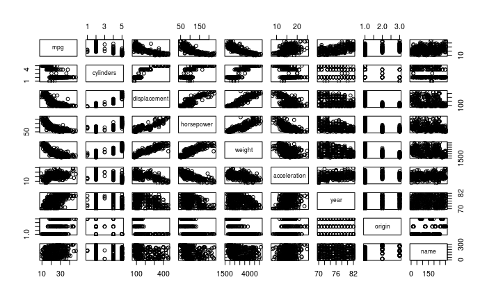

```r
pairs(Auto)
```

this function give us basic knowledge that where all the things are being going ’

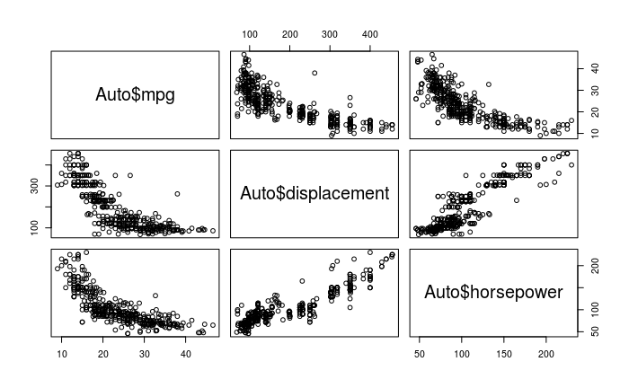

```r
pairs(~ Auto$mpg + Auto$displacement+Auto$horsepower)
```

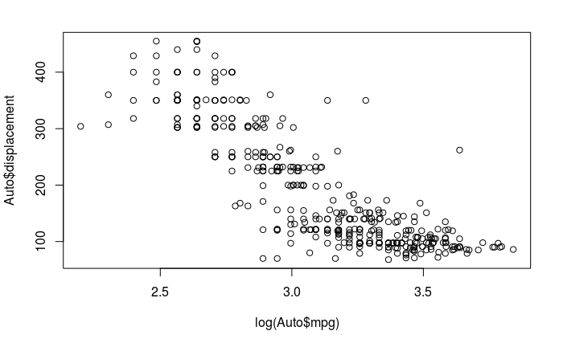

```r
plot(log(Auto$mpg),Auto$displacement)
```

here we can see that mpg and displacement curse is something like exponential so making a log make it a straight line so that we can easily use linear regression but there is chances that we increase Bayesian in it

```r
identify(Auto$mpg,Auto$horsepower,Auto$displacement)
```

```
Error in identify.default(Auto$mpg, Auto$horsepower, Auto$displacement) :
  plot.new has not been called yet
```

not getting that how to use this identity function

now lets get the summary of the whole data set to get it moving all right and keep it moving like all

```r
summary(Auto)
```

```
      mpg        cylinders  displacement     horsepower        weight      acceleration        year
 Min.   : 9.00   3:  4     Min.   : 68.0   Min.   : 46.0   Min.   :1613   Min.   : 8.00   Min.   :70.00
 1st Qu.:17.00   4:199     1st Qu.:105.0   1st Qu.: 75.0   1st Qu.:2225   1st Qu.:13.78   1st Qu.:73.00
 Median :22.75   5:  3     Median :151.0   Median : 93.5   Median :2804   Median :15.50   Median :76.00
 Mean   :23.45   6: 83     Mean   :194.4   Mean   :104.5   Mean   :2978   Mean   :15.54   Mean   :75.98
 3rd Qu.:29.00   8:103     3rd Qu.:275.8   3rd Qu.:126.0   3rd Qu.:3615   3rd Qu.:17.02   3rd Qu.:79.00
 Max.   :46.60             Max.   :455.0   Max.   :230.0   Max.   :5140   Max.   :24.80   Max.   :82.00

     origin                      name
 Min.   :1.000   amc matador       :  5
 1st Qu.:1.000   ford pinto        :  5
 Median :1.000   toyota corolla    :  5
 Mean   :1.577   amc gremlin       :  4
 3rd Qu.:2.000   amc hornet        :  4
 Max.   :3.000   chevrolet chevette:  4
                 (Other)           :365
```

```r
savehistory()
```